# Dragon Ball Supervised Learning Regression

## Problem Definition

### Context

- In the Dragon Ball universe, a character’s power level signifies their strength and battle potential.
- Machine learning regression techniques can help estimate power levels based on factors such as transformations, combat abilities, and species traits.
- Understanding these factors can benefit game balancing, fan discussions, and AI-generated rankings for characters.

## Importing Libraries and the Dataset

```python
# Mounting the drive
from google.colab import drive
drive.mount('/content/drive')
```

```python
# Used to ignore the warning given as output of the code
import warnings                                       # Ignore the warning given as output of the code
warnings.filterwarnings('ignore')

# Basic libraries of python for numeric and dataframe computations
import numpy as np                                    # Basic libraries numeric and dataframe computations
import pandas as pd

# Import Matplotlib the Basic library for data visualization
# Import seaborn - Slightly advanced library for data visualization
import matplotlib.pyplot as plt                       # Basic visualization library
import seaborn as sns

# Import the required library to compute the cosine similarity between two vectors


# Import defaultdict from collections A dictionary output that does not raise a key error
from collections import defaultdict                   # A dictionary output that does not raise a key error
```

## Load the Dataset

```python
# Loading the ratings dataset
data = pd.read_csv('/content/drive/MyDrive/My DS DA/Dragon Ball Z/data.csv')
```

## Data Overview

```python
data.sample(5)
```

|  | Name | Race | Gender | Power Level | Ki Blast | Melee Combat | Speed | Special Attack | Transformation | Speed_Original | Normalized_Power | Power_Score | Meta |
| --- | --- | --- | --- | --- | --- | --- | --- | --- | --- | --- | --- | --- | --- |
| 16 | Yamu | Human | Male | 1000 | Energy Blast | NaN | 1 | - | - | Slow | 0.00 | 0.30 | Yamu Human Energy Blast nan - - Male |
| 33 | Great Saiyaman | Saiyan | Male | 4500 | Justice Beam | Justice Punch | 3 | Saiyan Man Pose | - | Fast | 0.02 | 0.92 | Great Saiyaman Saiyan Justice Beam Justice Pun... |
| 50 | Bojack | Alien | Male | 40000 | Galactic Buster | Galactic Slam | 3 | Galactic Blow | Transformation | Fast | 0.20 | 1.04 | Bojack Alien Galactic Buster Galactic Slam Gal... |
| 8 | Chiaotzu | Human | Male | 1400 | Dodon Ray | Psychic Powers | 1 | Psychic Powers | - | Slow | 0.01 | 0.30 | Chiaotzu Human Dodon Ray Psychic Powers Psychi... |
| 63 | Upa | Human | Male | 10 | NaN | Martial Arts | 1 | NaN | - | Slow | 0.00 | 0.30 | Upa Human nan Martial Arts nan - Male |

Check for missing values

```python
data.isnull().sum()
```

|  | 0 |
| --- | --- |
| Name | 0 |
| Race | 0 |
| Gender | 0 |
| Power Level | 0 |
| Ki Blast | 20 |
| Melee Combat | 11 |
| Speed | 0 |
| Special Attack | 31 |
| Transformation | 0 |
| Speed_Original | 0 |
| Normalized_Power | 0 |
| Power_Score | 0 |
| Meta | 0 |

**dtype:** int64

```python
(data.isnull().sum() / data.shape[0])*100
```

|  | 0 |
| --- | --- |
| Name | 0.000000 |
| Race | 0.000000 |
| Gender | 0.000000 |
| Power Level | 0.000000 |
| Ki Blast | 29.411765 |
| Melee Combat | 16.176471 |
| Speed | 0.000000 |
| Special Attack | 45.588235 |
| Transformation | 0.000000 |
| Speed_Original | 0.000000 |
| Normalized_Power | 0.000000 |
| Power_Score | 0.000000 |
| Meta | 0.000000 |

**dtype:** float64

- mising values in columns are less than 50% and some values may be because characters do not have abilities or transformations.

Check for duplicated rows

```python
data.info()
```

```
<class 'pandas.core.frame.DataFrame'>
RangeIndex: 68 entries, 0 to 67
Data columns (total 13 columns):
 #   Column            Non-Null Count  Dtype
---  ------            --------------  -----
 0   Name              68 non-null     object
 1   Race              68 non-null     object
 2   Gender            68 non-null     object
 3   Power Level       68 non-null     int64
 4   Ki Blast          48 non-null     object
 5   Melee Combat      57 non-null     object
 6   Speed             68 non-null     int64
 7   Special Attack    37 non-null     object
 8   Transformation    68 non-null     object
 9   Speed_Original    68 non-null     object
 10  Normalized_Power  68 non-null     float64
 11  Power_Score       68 non-null     float64
 12  Meta              68 non-null     object
dtypes: float64(2), int64(2), object(9)
memory usage: 7.0+ KB
```

## Data Preprocessing and Feature Engineering

### Create a column named Battle Score

```python
# Convert relevant columns to numeric (handle any non-numeric values)
data["Power Level"] = pd.to_numeric(data["Power Level"], errors='coerce')
data["Speed"] = pd.to_numeric(data["Speed"], errors='coerce')
data["Normalized_Power"] = pd.to_numeric(data["Normalized_Power"], errors='coerce')
data["Power_Score"] = pd.to_numeric(data["Power_Score"], errors='coerce')

# Compute Battle Score
data["Battle_Score"] = (data["Power Level"] * data["Speed"]) + (data["Normalized_Power"] * data["Power_Score"])
```

```python
# Compute Battle Score and round to 2 decimal places
data["Battle_Score"] = ((data["Power Level"] * data["Speed"]) + (data["Normalized_Power"] * data["Power_Score"])).round(2)

# Display the first few rows to check
data[["Power Level", "Speed", "Normalized_Power", "Power_Score", "Battle_Score"]].head()
```

|  | Power Level | Speed | Normalized_Power | Power_Score | Battle_Score |
| --- | --- | --- | --- | --- | --- |
| 0 | 9000 | 3 | 0.04 | 0.93 | 27000.04 |
| 1 | 8500 | 3 | 0.04 | 0.93 | 25500.04 |
| 2 | 8000 | 3 | 0.04 | 0.93 | 24000.04 |
| 3 | 7500 | 3 | 0.04 | 0.93 | 22500.04 |
| 4 | 7800 | 3 | 0.04 | 0.93 | 23400.04 |

```python
# Display the first few rows to check
data.head()
```

|  | Name | Race | Gender | Power Level | Ki Blast | Melee Combat | Speed | Special Attack | Transformation | Speed_Original | Normalized_Power | Power_Score | Meta | Battle_Score |
| --- | --- | --- | --- | --- | --- | --- | --- | --- | --- | --- | --- | --- | --- | --- |
| 0 | Goku | Saiyan | Male | 9000 | Kamehameha | Dragon Fist | 3 | Spirit Bomb | Super Saiyan | Fast | 0.04 | 0.93 | Goku Saiyan Kamehameha Dragon Fist Spirit Bomb... | 27000.04 |
| 1 | Vegeta | Saiyan | Male | 8500 | Galick Gun | Big Bang | 3 | Final Flash | Super Saiyan | Fast | 0.04 | 0.93 | Vegeta Saiyan Galick Gun Big Bang Final Flash ... | 25500.04 |
| 2 | Piccolo | Namekian | Male | 8000 | Special Beam Cannon | Namekian Punch | 3 | Hellzone Grenade | Fuse with Kami | Fast | 0.04 | 0.93 | Piccolo Namekian Special Beam Cannon Namekian ... | 24000.04 |
| 3 | Gohan | Half-Saiyan | Male | 7500 | Masenko | Soaring Dragon Strike | 3 | Father-Son Kamehameha | Super Saiyan 2 | Fast | 0.04 | 0.93 | Gohan Half-Saiyan Masenko Soaring Dragon Strik... | 22500.04 |
| 4 | Future Trunks | Half-Saiyan | Male | 7800 | Burning Attack | Sword Strike | 3 | Heat Dome Attack | Super Saiyan | Fast | 0.04 | 0.93 | Future Trunks Half-Saiyan Burning Attack Sword... | 23400.04 |

```python
data.isnull().sum()
```

|  | 0 |
| --- | --- |
| Name | 0 |
| Race | 0 |
| Gender | 0 |
| Power Level | 0 |
| Ki Blast | 20 |
| Melee Combat | 11 |
| Speed | 0 |
| Special Attack | 31 |
| Transformation | 0 |
| Speed_Original | 0 |
| Normalized_Power | 0 |
| Power_Score | 0 |
| Meta | 0 |
| Battle_Score | 0 |

**dtype:** int64

```python
data.duplicated().sum()
```

```
0
```

## Data Preprocessing & Feature Engineering

```python
data.columns.to_list()
```

```
['Name',
 'Race',
 'Gender',
 'Power Level',
 'Ki Blast',
 'Melee Combat',
 'Speed',
 'Special Attack',
 'Transformation',
 'Speed_Original',
 'Normalized_Power',
 'Power_Score',
 'Meta',
 'Battle_Score']
```

Drop Columns

Drop Name, Gender,

```python
data = data.drop(['Name', 'Meta', 'Gender', 'Normalized_Power', 'Power_Score', 'Speed_Original'], axis = 1)
data.head()
```

|  | Race | Power Level | Ki Blast | Melee Combat | Speed | Special Attack | Transformation | Battle_Score |
| --- | --- | --- | --- | --- | --- | --- | --- | --- |
| 0 | Saiyan | 9000 | Kamehameha | Dragon Fist | 3 | Spirit Bomb | Super Saiyan | 27000.04 |
| 1 | Saiyan | 8500 | Galick Gun | Big Bang | 3 | Final Flash | Super Saiyan | 25500.04 |
| 2 | Namekian | 8000 | Special Beam Cannon | Namekian Punch | 3 | Hellzone Grenade | Fuse with Kami | 24000.04 |
| 3 | Half-Saiyan | 7500 | Masenko | Soaring Dragon Strike | 3 | Father-Son Kamehameha | Super Saiyan 2 | 22500.04 |
| 4 | Half-Saiyan | 7800 | Burning Attack | Sword Strike | 3 | Heat Dome Attack | Super Saiyan | 23400.04 |

## EDA

- [EDA](https://colab.research.google.com/drive/11_RHgukIdfJhYBmV1efLdg5AxEUDSQn3?usp=sharing)
- [Unsupervised Learning](https://colab.research.google.com/drive/1CMT8F7UpDIHC7l4nXKm9RJCF3CKiu9lt?usp=sharing)
- [Supervised Learning Regression EDA](https://colab.research.google.com/drive/1Ajn_UUD0WagAUDcXMLbiUYNrRAXAnSSm?usp=sharing)
- [Supervised Learning Regression with Lasso and Ridge](https://colab.research.google.com/drive/1CxChCQxS-7xTKGTyo1hDvFhqY8ka6Kqm?usp=sharing)
- [Dragon Ball Supervised Learning Classification](https://colab.research.google.com/drive/1HZtd-i1sUiCA2E5UgGSERtrXP2WqxqAg?usp=sharing)

```python
num_cols = ['Speed', 'Power Level', 'Battle_Score']

cat_cols = ['Race', 'Ki Blast', 'Melee Combat', 'Special Attack', 'Transformation']
```

### Univariate Analysis

```python
# Function to plot a boxplot and a histogram along the same scale

def histogram_boxplot(data, feature, figsize=(12, 7), kde=False, bins=None):
    """
    Boxplot and histogram combined

    data: dataframe
    feature: dataframe column
    figsize: size of figure (default (12,7))
    kde: whether to the show density curve (default False)
    bins: number of bins for histogram (default None)
    """
    f2, (ax_box2, ax_hist2) = plt.subplots(
        nrows = 2,      # Number of rows of the subplot grid = 2
        sharex = True,  # x-axis will be shared among all subplots
        gridspec_kw = {"height_ratios": (0.25, 0.75)},
        figsize = figsize,
    )                   # Creating the 2 subplots
    sns.boxplot(data = data, x = feature, ax = ax_box2, showmeans = True, color = "violet"
    )                   # Boxplot will be created and a star will indicate the mean value of the column
    sns.histplot(
        data = data, x = feature, kde = kde, ax = ax_hist2, bins = bins, palette = "winter"
    ) if bins else sns.histplot(
        data = data, x = feature, kde = kde, ax = ax_hist2
    )                   # For histogram
    ax_hist2.axvline(
        data[feature].mean(), color = "green", linestyle = "--"
    )                   # Add mean to the histogram
    ax_hist2.axvline(
        data[feature].median(), color = "black", linestyle = "-"
    )                   # Add median to the histogram
```

Battle Score

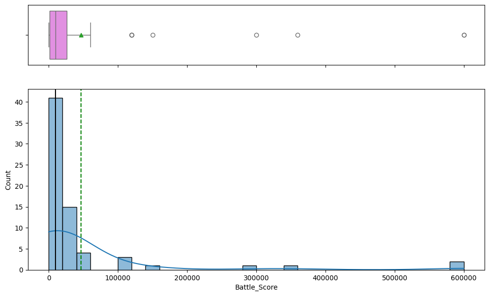

```python
histogram_boxplot(data, "Battle_Score", kde = True, bins = 30)
```

- Observations
  - Right-Skewed Distribution – The Battle_Score values are heavily skewed to the right, indicating that most characters have low scores, while a few have extremely high scores.
- Presence of Outliers – The box plot at the top shows multiple outliers, meaning some characters have significantly higher battle scores compared to the majority.
- Concentration of Data – The histogram shows that most battle scores are clustered below 100,000, with very few extreme values extending towards 600,000.
- KDE Plot Shows Skewness – The Kernel Density Estimation (KDE) curve confirms that the majority of scores fall in the lower range, with a long tail extending to the right.
- Potential Data Imbalance – The extreme variation suggests that some characters may dominate battles, and further feature engineering or transformation (e.g., log transformation) may be needed to make the data more normally distributed.

Speed

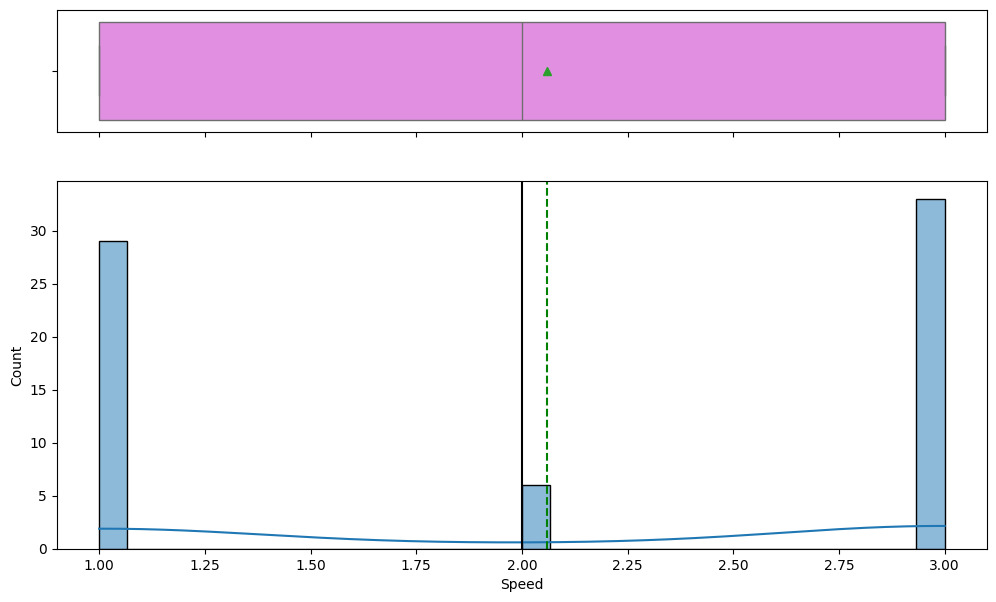

```python
histogram_boxplot(data, "Speed", kde = True, bins = 30)
```

- Observations
  - Categorical-Like Distribution – The histogram suggests that Speed takes on discrete values (1, 2, 3) rather than a continuous range, indicating it may be ordinal rather than numerical.
  - Tri-Modal Distribution – There are three distinct peaks at values 1, 2, and 3, suggesting that speed is grouped into three levels.
  - Evenly Distributed Counts – The count of observations for Speed = 1 and Speed = 3 appears to be roughly equal, with fewer instances of Speed = 2.
  - No Outliers in Box Plot – The box plot does not show extreme outliers, but since the data is likely ordinal, outliers may not be as meaningful.
  - Kernel Density Estimation (KDE) May Be Misleading – Since speed is discrete, using a KDE isn't ideal, as it assumes a continuous distribution.

Power Level

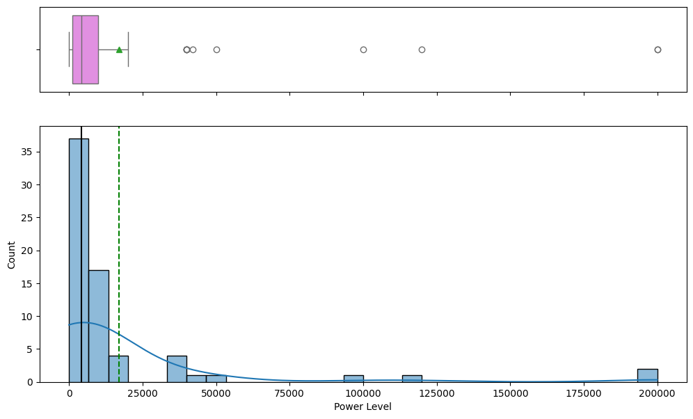

```python
histogram_boxplot(data, "Power Level", kde = True, bins = 30)
```

- Observations
  - Highly Skewed Distribution – The Power Level feature exhibits a right-skewed (positively skewed) distribution, meaning most values are low, while a few are extremely high.
- Presence of Extreme Outliers – The boxplot shows several extreme outliers far beyond the upper whisker, suggesting a few characters have significantly higher power levels than the rest.
- Majority of Values Clustered at Lower Levels – The histogram shows that most characters have Power Levels below 25,000, while only a few exceed 100,000+. Kernel Density Estimation (KDE) Reinforces the Skewness – The KDE curve highlights a long tail, reinforcing the imbalance in distribution.

### Bivariate Analysis

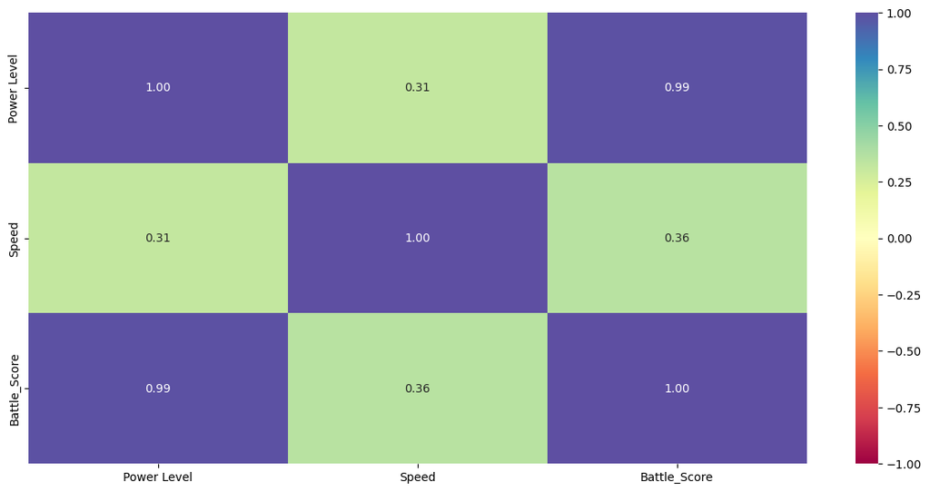

```python
# Exclude non-numeric columns
numeric_data = data.select_dtypes(include=np.number)

# Create heatmap
plt.figure(figsize=(15, 7))
sns.heatmap(numeric_data.corr(), annot=True, vmin=-1, vmax=1, fmt=".2f", cmap="Spectral")
plt.show()
```

- Observations
  - Strong Positive Correlation between Power Level and Battle Score (0.99)
    - This indicates that Power Level is almost entirely responsible for determining the Battle Score.
    - This could suggest redundancy, meaning Power Level alone might be enough to estimate Battle Score without the need for additional features.
  - Moderate Positive Correlation between Speed and Battle Score (0.36)
    - Speed contributes moderately to Battle Score but is not the dominant factor.
    - This suggests that speed alone does not significantly influence battle performance.
  - Weak Positive Correlation between Power Level and Speed (0.31)
    - A slight relationship exists, meaning characters with higher power levels tend to have slightly higher speed, but this is not a strong trend.
    - This suggests that Speed and Power Level are relatively independent features, which is good for model diversity.

## Data Preparation for Model Building

- Before we proceed to build a model, we'll have to encode categorical features.
- Separate the independent variables and dependent Variables.
- We'll split the data into train and test to be able to evaluate the model that we train on the training data.

```python
# Creating dummy variables for the categorical columns
# drop_first=True is used to avoid redundant variables
data = pd.get_dummies(
    data,
    columns = data.select_dtypes(include = ["object", "category"]).columns.tolist(),
    drop_first = True,
)
```

```python
data.head(5)
```

|  | Power Level | Speed | Battle_Score | Race_Android | Race_Angel | Race_Bio-Android | Race_Demon | Race_Frost Demon | Race_Genie | Race_Grasshopper | ... | Transformation_Absorption | Transformation_Final Form | Transformation_Fuse with Kami | Transformation_Majin Form | Transformation_Merge with Piccolo | Transformation_Perfect Form | Transformation_Super Saiyan | Transformation_Super Saiyan 2 | Transformation_Transformation | Transformation_Various Forms |
| --- | --- | --- | --- | --- | --- | --- | --- | --- | --- | --- | --- | --- | --- | --- | --- | --- | --- | --- | --- | --- | --- |
| 0 | 9000 | 3 | 27000.04 | False | False | False | False | False | False | False | ... | False | False | False | False | False | False | True | False | False | False |
| 1 | 8500 | 3 | 25500.04 | False | False | False | False | False | False | False | ... | False | False | False | False | False | False | True | False | False | False |
| 2 | 8000 | 3 | 24000.04 | False | False | False | False | False | False | False | ... | False | False | True | False | False | False | False | False | False | False |
| 3 | 7500 | 3 | 22500.04 | False | False | False | False | False | False | False | ... | False | False | False | False | False | False | False | True | False | False |
| 4 | 7800 | 3 | 23400.04 | False | False | False | False | False | False | False | ... | False | False | False | False | False | False | True | False | False | False |

5 rows × 141 columns

```python
# Separating independent variables and the target variable
x = data.drop('Battle_Score',axis=1)

y = data['Battle_Score']
```

```python
from sklearn.model_selection import train_test_split

# Splitting the dataset into train and test datasets
x_train, x_test, y_train, y_test = train_test_split(x, y, test_size = 0.2, shuffle = True, random_state = 1)
```

```python
# Checking the shape of the train and test data
print("Shape of Training set : ", x_train.shape)
print("Shape of test set : ", x_test.shape)
```

```
Shape of Training set :  (54, 140)
Shape of test set :  (14, 140)
```

## Model Building

- We will be using different metrics functions defined in sklearn like RMSE, MAE, 𝑅2, Adjusted 𝑅2, and MAPE for regression model evaluation. We will define a function to calculate these metrics.
- The mean absolute percentage error (MAPE) measures the accuracy of predictions as a percentage and can be calculated as the average absolute percentage error for all data points. The absolute percentage error is defined as the predicted value minus actual value divided by actual value. It works best if there are no extreme values in the data and none of the actual values are 0.

```python
# Function to compute adjusted R-squared
def adj_r2_score(predictors, targets, predictions):
    r2 = r2_score(targets, predictions)
    n = predictors.shape[0]
    k = predictors.shape[1]
    return 1 - ((1 - r2) * (n - 1) / (n - k - 1))


# Function to compute MAPE
def mape_score(targets, predictions):
    return np.mean(np.abs(targets - predictions) / targets) * 100


# Function to compute different metrics to check performance of a regression model
def model_performance_regression(model, predictors, target):
    """
    Function to compute different metrics to check regression model performance

    model: regressor
    predictors: independent variables
    target: dependent variable
    """

    pred = model.predict(predictors)                  # Predict using the independent variables
    r2 = r2_score(target, pred)                       # To compute R-squared
    adjr2 = adj_r2_score(predictors, target, pred)    # To compute adjusted R-squared
    rmse = np.sqrt(mean_squared_error(target, pred))  # To compute RMSE
    mae = mean_absolute_error(target, pred)           # To compute MAE
    mape = mape_score(target, pred)                   # To compute MAPE

    # Creating a dataframe of metrics
    df_perf = pd.DataFrame(
        {
            "RMSE": rmse,
            "MAE": mae,
            "R-squared": r2,
            "Adj. R-squared": adjr2,
            "MAPE": mape,
        },
        index=[0],
    )

    return df_perf
```

### Decision Trees

- Decision Trees are a type of supervised machine learning algorithm that can be used for both classification and regression tasks. They are often used in business and industry to make decisions based on data, and are particularly useful for tasks that require decision-making based on a set of conditions.
- The goal of the algorithm is to find the tree that provides the best predictions on the training data, while also being as simple and interpretable as possible.

```python
from sklearn.metrics import r2_score
from sklearn.metrics import mean_squared_error
from sklearn.metrics import mean_absolute_error
```

```python
from sklearn.tree import DecisionTreeRegressor


# Decision Tree Regressor
dt_regressor = DecisionTreeRegressor(random_state = 1)

# Fitting the model
dt_regressor.fit(x_train, y_train)

# Model Performance on the test data, i.e., prediction
dt_regressor_perf_test = model_performance_regression(dt_regressor, x_test, y_test)

dt_regressor_perf_test
```

|  | RMSE | MAE | R-squared | Adj. R-squared | MAPE |
| --- | --- | --- | --- | --- | --- |
| 0 | 13843.589744 | 5600.011429 | 0.816439 | 1.01879 | 49.511638 |

- Observations
  - RMSE (Root Mean Squared Error) = 13,843.59
    - The model has a relatively high RMSE, indicating significant error in the predictions.
  - MAE (Mean Absolute Error) = 5,600.01
    - On average, the model's predictions deviate from actual values by about 5,600 units. This suggests that while some predictions may be close, others have large deviations.
  - R-squared = 0.8164
    - The model explains approximately 81.6% of the variance in the target variable, indicating a good fit but still leaving room for improvement.
  - Adjusted R-squared = 1.01879
    - This value seems unrealistic, suggesting possible overfitting or an issue with the calculation.
  - MAPE (Mean Absolute Percentage Error) = 49.51%
    - The average percentage error is quite high, meaning the model’s predictions are not very reliable, especially if the dataset contains large variations.

Let's visualize the decision tree and examine the tree's decision rules. Visualizing a Decision Tree can help you understand how the algorithm works and interpret its predictions. Visualizing the tree can help us to:

- Identify the root node: The first node at the top of the tree is called the root node. It represents the entire dataset and is used to split the data into two or more homogeneous subsets.
- Identify the internal nodes: The nodes that are not leaf nodes are called internal nodes. They represent a decision or a test on a feature and are used to split the data into smaller subsets based on the feature value.
- Identify the leaf nodes: The nodes at the bottom of the tree are called leaf nodes. They represent the output or the class label of the data after going through all the splits in the tree.
- Follow a path from the root to a leaf node: To interpret a decision tree, you can follow a path from the root node to a leaf node. Along the path, you can see the tests performed on the features, and based on the test results, the data is split into smaller subsets.
- Analyze the feature importance: You can analyze the feature importance by looking at the splits in the tree. The features used to split the data at the top of the tree are the most important features, as they have the highest impact on the decision.
- Analyze the class distribution: You can analyze the class distribution at the leaf nodes to understand how the decision tree predicts the class labels. If the majority of the samples in a leaf node belong to a particular class, the decision tree predicts that class for the new data.
- Explain the decision: Finally, you can explain the decision made by the decision tree by summarizing the path taken from the root to the leaf node and the class label predicted at the leaf node. You can also explain the importance of the features used in the decision and how they influence the final prediction.

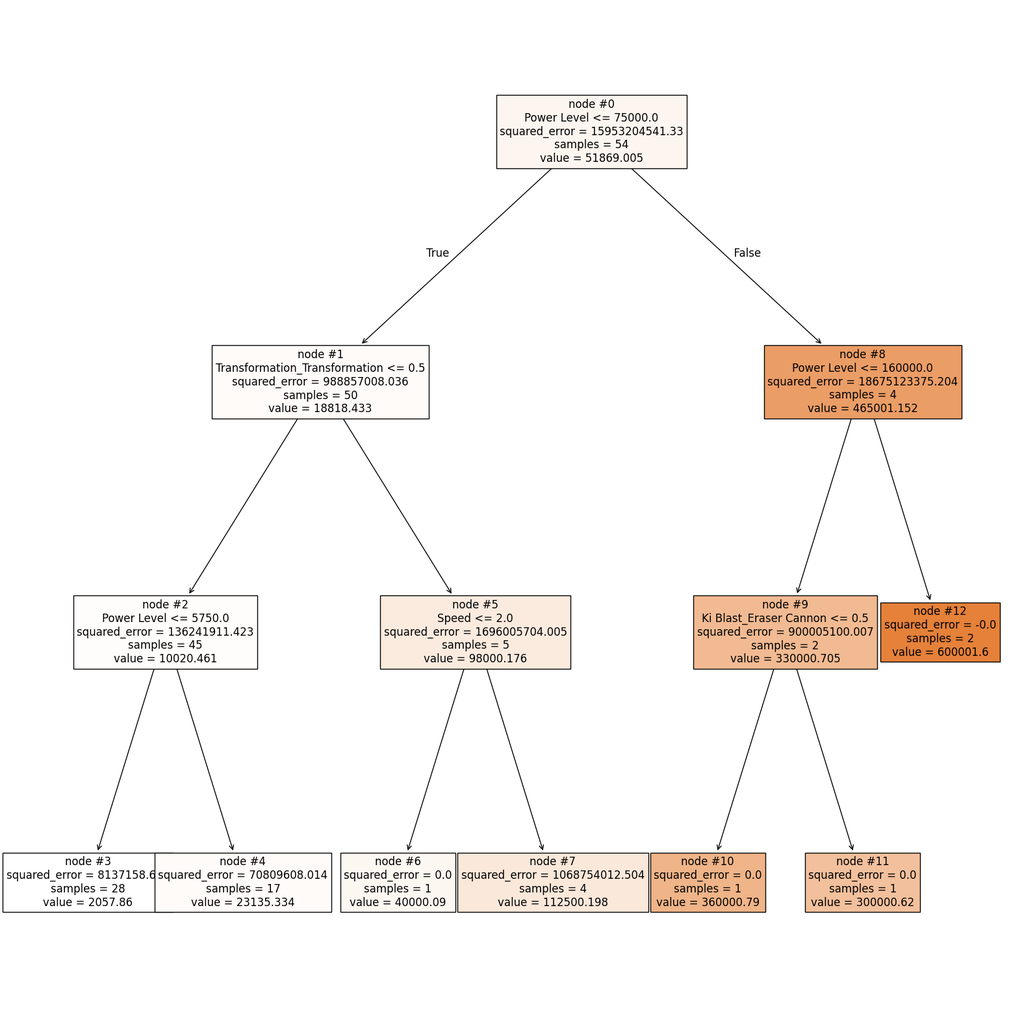

```python
from sklearn import tree
features = list(x.columns)

# Building the model with max_depth=3
dt_regressor_visualize = DecisionTreeRegressor(random_state = 1, max_depth=3)

# Fitting the model
dt_regressor_visualize.fit(x_train, y_train)


plt.figure(figsize = (20, 20))
tree.plot_tree(dt_regressor_visualize, feature_names = features, filled = True, fontsize = 12,
               node_ids = True, class_names = None)
plt.show()
```

```python
print(tree.export_text(dt_regressor_visualize, feature_names=x_train.columns.tolist(), show_weights=True))
```

```
|--- Power Level <= 75000.00
|   |--- Transformation_Transformation <= 0.50
|   |   |--- Power Level <= 5750.00
|   |   |   |--- value: [2057.86]
|   |   |--- Power Level >  5750.00
|   |   |   |--- value: [23135.33]
|   |--- Transformation_Transformation >  0.50
|   |   |--- Speed <= 2.00
|   |   |   |--- value: [40000.09]
|   |   |--- Speed >  2.00
|   |   |   |--- value: [112500.20]
|--- Power Level >  75000.00
|   |--- Power Level <= 160000.00
|   |   |--- Ki Blast_Eraser Cannon <= 0.50
|   |   |   |--- value: [360000.79]
|   |   |--- Ki Blast_Eraser Cannon >  0.50
|   |   |   |--- value: [300000.62]
|   |--- Power Level >  160000.00
|   |   |--- value: [600001.60]
```

### Bagging Regressor

- Bagging (short for Bootstrap Aggregating) is an ensemble learning technique that involves training multiple models on different subsets of the training data and then combining their predictions. The idea is to reduce variance and overfitting by averaging the predictions of many models.
- A Bagging Regressor is a type of Bagging algorithm used for regression tasks. It involves training multiple regression models (e.g., Decision Trees) on different subsets of the training data and then combining their predictions by taking the average.
- The Bagging Regressor works by generating multiple subsets of the training data by randomly selecting data points with replacement (i.e., allowing the same data point to be selected more than once in the same subset). Each subset is used to train a separate regression model, and the predictions of these models are combined by taking their average.

```python
from sklearn.ensemble import BaggingRegressor

# Bagging Regressor
bagging_estimator = BaggingRegressor(random_state = 1)

# Fitting the model
bagging_estimator.fit(x_train, y_train)

# Model Performance on the test data
bagging_estimator_perf_test = model_performance_regression(bagging_estimator, x_test, y_test)

bagging_estimator_perf_test
```

|  | RMSE | MAE | R-squared | Adj. R-squared | MAPE |
| --- | --- | --- | --- | --- | --- |
| 0 | 10412.049558 | 4782.973143 | 0.896162 | 1.010629 | 35.853285 |

### Random Forest Regressor

- Random Forest is another ensemble learning technique that combines multiple Decision Trees to create a more robust and accurate model. Like Bagging, it involves training multiple models on different subsets of the training data, but with an additional twist: at each split in the tree, only a random subset of the available features is considered for splitting.
- This helps to reduce the correlation between the trees in the forest and improves their overall accuracy.
- A Random Forest works by training multiple Decision Trees on different subsets of the training data, and then combining their predictions by taking their average. The key difference from Bagging is that at each split in the tree, only a random subset of the features is considered for splitting.
- The algorithm works as follows:
  - Generate multiple random subsets of the training data (with replacement).
  - For each subset, train a Decision Tree on a random subset of the features.
  - Make predictions for new data by averaging the predictions of all the trees in the forest.
  - The number of trees in the forest and the number of features considered at each split are hyperparameters that can be tuned to optimize the performance of the model.

The Random Forest algorithm doesn't have any specific equations, but it involves training multiple Decision Trees on different subsets of the training data with a random subset of the features considered at each split.

```python
from sklearn.ensemble import RandomForestRegressor

# Random Forest Regressor
rf_regressor = RandomForestRegressor(n_estimators = 100, random_state = 1)

# Fitting the model
rf_regressor.fit(x_train, y_train)

# Model Performance on the test data
rf_regressor_perf_test = model_performance_regression(rf_regressor, x_test, y_test)

rf_regressor_perf_test
```

|  | RMSE | MAE | R-squared | Adj. R-squared | MAPE |
| --- | --- | --- | --- | --- | --- |
| 0 | 12612.793962 | 6299.807757 | 0.847628 | 1.015597 | 37.146248 |

- RMSE (Root Mean Squared Error): 12,612.79 — Higher than the Bagging Regressor (~10,412), indicating slightly worse performance in terms of prediction error.
- MAE (Mean Absolute Error): 6,299.81 — Higher than the Bagging Regressor (~4,782), suggesting less precise predictions.
- R² Score: 0.8476 — A good fit but slightly worse than Bagging (0.896), indicating a lower proportion of variance explained by the model.
- Adjusted R² Score: 1.0156 — Close to 1, suggesting that adding more features may not significantly improve the model.
- MAPE (Mean Absolute Percentage Error): 37.14% — Higher than Bagging (35.85%), indicating higher relative errors.

### AdaBoost

- Adaboost (short for Adaptive Boosting) is a type of boosting algorithm that combines multiple weak classifiers to create a stronger classifier. A weak classifier is a classifier that performs only slightly better than random guessing.
- Adaboost works by training multiple weak classifiers on different subsets of the training data, and then combining their predictions to make a final prediction. The algorithm works as follows:
- Assign equal weights to all the training examples. Train a weak classifier on a subset of the training data. Increase the weights of the misclassified examples. Train another weak classifier on the same subset of data but with the weights adjusted to give more importance to the misclassified examples. Repeat steps 3-4 for a specified number of iterations or until the error rate is sufficiently low. Combine the predictions of all the weak classifiers to make a final prediction. The key idea behind Adaboost is that by giving more weight to the misclassified examples, the algorithm can focus on the examples that are more difficult to classify and improve its overall accuracy.

```python
# Importing AdaBoost Regressor
from sklearn.ensemble import AdaBoostRegressor

# AdaBoost Regressor
ada_regressor = AdaBoostRegressor(random_state=1)

# Fitting the model
ada_regressor.fit(x_train, y_train)

# Model Performance on the test data
ada_regressor_perf_test = model_performance_regression(ada_regressor, x_test, y_test)

ada_regressor_perf_test
```

|  | RMSE | MAE | R-squared | Adj. R-squared | MAPE |
| --- | --- | --- | --- | --- | --- |
| 0 | 13292.027551 | 6865.046474 | 0.830774 | 1.017322 | 4880.661741 |

- Observations
  - RMSE (Root Mean Squared Error): 13,292.03 — Higher than both Bagging (~10,412) and Random Forest (~12,612), indicating greater prediction error.
  - MAE (Mean Absolute Error): 6,865.05 — Highest among the ensemble models, meaning larger absolute errors in predictions.
  - R² Score: 0.8308 — Slightly lower than Random Forest (0.847) and Bagging (0.896), meaning it explains less variance in the data.
  - Adjusted R² Score: 1.0173 — Similar to the other models, showing minimal improvement from additional features.
  - MAPE (Mean Absolute Percentage Error): 4880.66 — Extremely high, suggesting poor relative performance.

### Gradient Boosting Regressor

- Gradient Boosting is another boosting algorithm that combines multiple weak learners to create a strong learner. The difference between Adaboost and Gradient Boosting is that the former assigns different weights to different data points, while the latter fits the model to the residual errors of the previous model.
- Gradient Boosting works by sequentially adding weak learners to the model and updating the weights of the training examples based on the residual errors of the previous models
- Train the weak learner on the training data.
- Compute the predictions of the weak learner.
- Compute the residual errors of the previous model by subtracting the predicted values from the actual values.
- Fit the weak learner to the residual errors.
- Update the weights of the training examples based on the fitted residual errors.
- Combine the predictions of all the weak learners to make a final prediction.
- The key idea behind Gradient Boosting is that by fitting the model to the residual errors of the previous model, it can focus on the examples that were not well predicted by the previous model and improve its overall accuracy.

```python
# Importing Gradient Boosting Regressor
from sklearn.ensemble import GradientBoostingRegressor

# Gradient Boosting Regressor
grad_regressor = GradientBoostingRegressor(random_state=1)

# Fitting the model
grad_regressor.fit(x_train, y_train)

# Model Performance on the test data
grad_regressor_perf_test = model_performance_regression(grad_regressor, x_test, y_test)

grad_regressor_perf_test
```

|  | RMSE | MAE | R-squared | Adj. R-squared | MAPE |
| --- | --- | --- | --- | --- | --- |
| 0 | 9398.121778 | 4139.917182 | 0.915401 | 1.00866 | 4041.16315 |

### XGBoost Regressor

- GBoost (short for Extreme Gradient Boosting) is a highly optimized implementation of the Gradient Boosting algorithm. It was developed by Tianqi Chen at the University of Washington and is widely used in data science competitions.
- XGBoost works by sequentially adding weak learners to the model and updating the weights of the training examples based on the residual errors of the previous models.
- Regularization: XGBoost includes L1 and L2 regularization to prevent overfitting. Tree Pruning: XGBoost includes a technique called "tree pruning" to remove irrelevant features and reduce the complexity of the model. Weighted Quantile Sketch: XGBoost uses a weighted quantile sketch algorithm to speed up the computation of split points in the decision trees. Equations
- The XGBoost algorithm involves computing the negative gradient of the loss function with respect to the predicted values and using it to update the model. The equation for computing the negative gradient is the same as in Gradient Boosting.

```python
# Installing the xgboost library using the 'pip' command
# !pip install xgboost
```

```python
# Importing XGBoost Regressor
from xgboost import XGBRegressor

# XGBoost Regressor
xgb = XGBRegressor(random_state = 1)

# Fitting the model
xgb.fit(x_train,y_train)

# Model Performance on the test data
xgb_perf_test = model_performance_regression(xgb, x_test, y_test)

xgb_perf_test
```

|  | RMSE | MAE | R-squared | Adj. R-squared | MAPE |
| --- | --- | --- | --- | --- | --- |
| 0 | 12464.021595 | 4016.720885 | 0.851201 | 1.015231 | 3087.238464 |

## Models' Performance Comparison

- Comparing different machine learning models is an important step in the modeling process, as it allows us to understand the strengths and weaknesses of each model, and to choose the best one for a particular task.
- In the context of regression, we can compare models based on various performance metrics, such as Mean Squared Error (MSE), Root Mean Squared Error (RMSE), Mean Absolute Error (MAE), R-squared, Adjusted R-squared and others.

```python
models_test_comp_df = pd.concat(
    [
        dt_regressor_perf_test.T,
        bagging_estimator_perf_test.T,
        rf_regressor_perf_test.T,
        ada_regressor_perf_test.T,
        grad_regressor_perf_test.T,
        xgb_perf_test.T
    ],
    axis = 1,
)

models_test_comp_df.columns = [
    "Decision tree regressor",
    "Bagging Regressor",
    "Random Forest regressor",
    "Ada Boost Regressor",
    "Gradient Boosting Regressor",
    "XG Boost Regressor"]

print("Test performance comparison:")

models_test_comp_df.T
```

```
Test performance comparison:
```

|  | RMSE | MAE | R-squared | Adj. R-squared | MAPE |
| --- | --- | --- | --- | --- | --- |
| Decision tree regressor | 13843.589744 | 5600.011429 | 0.816439 | 1.018790 | 49.511638 |
| Bagging Regressor | 10412.049558 | 4782.973143 | 0.896162 | 1.010629 | 35.853285 |
| Random Forest regressor | 12612.793962 | 6299.807757 | 0.847628 | 1.015597 | 37.146248 |
| Ada Boost Regressor | 13292.027551 | 6865.046474 | 0.830774 | 1.017322 | 4880.661741 |
| Gradient Boosting Regressor | 9398.121778 | 4139.917182 | 0.915401 | 1.008660 | 4041.163150 |
| XG Boost Regressor | 12464.021595 | 4016.720885 | 0.851201 | 1.015231 | 3087.238464 |

Model Performance Comparison & Ranking

The table below ranks models based on key evaluation metrics:

[output not shown]

**Ranking Justification**

**Final Recommendation** **Gradient Boosting Regressor should be tuned first** for optimal performance.

- **Hyperparameter tuning** (learning rate, depth, estimators) could further **reduce errors**.
- If **interpretability or efficiency is needed**, consider **Bagging or XGBoost**.

Choosing the Models for Tuning Hyperparameters

- Choosing the final model from the set of compared models depends on various factors. Here are some steps to help you make a decision:
  - Look at the evaluation metrics: Check the evaluation metrics of the models that you have compared. Choose the model that performs the best based on your criteria. However, it is important to keep in mind that the model with the best performance on the training set may not necessarily be the best on the test set. Therefore, it is important to also consider the model's performance on the test set.
  - Overfitting: Check for overfitting in the models. A model that overfits the data may perform very well on the training set but poorly on the test set. One way to check for overfitting is by comparing the performance of the model on the training set and the test set. If the difference in performance is large, it may indicate overfitting. Therefore, it is better to choose a model that has a good balance between performance on the training set and the test set.
  - Model complexity: Consider the complexity of the models. A more complex model may fit the data better but may also overfit the data. Therefore, it is better to choose a model that has a good balance between simplicity and performance.
  - Interpretability: Consider the interpretability of the models. Some models, such as decision trees, are more interpretable than others, such as neural networks. If interpretability is important for your application, it may be better to choose a more interpretable model.
  - Runtime: Consider the runtime of the models. Some models may take longer to train and predict than others. If runtime is a concern, it may be better to choose a model that is faster to train and predict.

## Tuning the Model

Gradient Boosting Regressor

```python
#### Using GridSearchCV
from sklearn.model_selection import GridSearchCV

# Initialize the model
gb_tuned = GradientBoostingRegressor(random_state=1)

# Grid of parameters to choose from
gb_parameters = {
    "n_estimators": [100, 110, 120],
    "max_depth": [5, 7, None],
    "max_features": [0.8, 1]
}

# Run the grid search
gb_grid_obj = GridSearchCV(gb_tuned, gb_parameters, scoring="neg_mean_squared_error", cv=5)

# Fit GridSearchCV
gb_grid_obj.fit(x_train, y_train)

# Set the gb_tuned regressor to the best combination of parameters
gb_tuned_regressor = gb_grid_obj.best_estimator_

# Retrain the best model found on the full training set
gb_tuned_regressor.fit(x_train, y_train)

# Model Performance on the test data
gb_tuned_regressor_perf_test = model_performance_regression(gb_tuned_regressor, x_test, y_test)

# Display results
gb_tuned_regressor_perf_test
```

|  | RMSE | MAE | R-squared | Adj. R-squared | MAPE |
| --- | --- | --- | --- | --- | --- |
| 0 | 21684.950042 | 9915.769331 | 0.549598 | 1.046104 | 57.408546 |

- Observations
  - Significant Performance Drop
    - The RMSE (21684.95) and MAE (9915.77) have increased drastically compared to the untuned model, indicating that the tuning process negatively impacted the model's generalization.
  - Lower R-Squared Score (0.55)
    - The R-squared value has significantly dropped from 0.91 (before tuning) to 0.55, suggesting the model explains far less variance in the target variable after tuning.
  - Overfitting to Poor Hyperparameters
    - Despite hyperparameter tuning, the selected parameters might have overfit the training data, leading to worse test performance.
  - Higher MAPE (57.4%)
    - The Mean Absolute Percentage Error (MAPE) suggests poor generalization, meaning the predictions deviate significantly from the actual values.
  - Possible Parameter Mismatch
    - The tuning parameters (max_depth, max_features, and n_estimators) may not be suitable for this dataset, leading to a suboptimal model.

RandomizedSearch

```python
# #### Using RandomizedSearchCV
from sklearn.model_selection import RandomizedSearchCV
from scipy.stats import randint, uniform

# Initialize the model
rf_tuned = RandomForestRegressor(random_state=1)

# Define the parameter distributions for randomized search
rf_parameters = {
    "n_estimators": randint(100, 121),  # Adjust the range as needed
    "max_depth": [5, 7, None],  # Different depths to test
    "max_features": [0.8, 1]  # Maximum number of features to consider
}

# Run the randomized search
rf_random_search = RandomizedSearchCV(
    rf_tuned,
    param_distributions=rf_parameters,
    n_iter=10,  # Adjust the number of iterations as needed
    scoring='neg_mean_squared_error',
    cv=5,
    random_state=1,
    n_jobs=-1
)

# Fit RandomizedSearchCV
rf_random_search.fit(x_train, y_train)

# Get the best estimator
rf_tuned_regressor = rf_random_search.best_estimator_

# Retrain the best model found on the full training set
rf_tuned_regressor.fit(x_train, y_train)

# Model performance on the test data
rf_tuned_regressor_perf_test = model_performance_regression(rf_tuned_regressor, x_test, y_test)

# Display results
rf_tuned_regressor_perf_test
```

|  | RMSE | MAE | R-squared | Adj. R-squared | MAPE |
| --- | --- | --- | --- | --- | --- |
| 0 | 14326.686301 | 7274.295223 | 0.803404 | 1.020124 | 39.677239 |

- Observations
  - RMSE (Root Mean Squared Error) = 14,326.69
    - This is relatively high, indicating that the model has a significant prediction error.
  - MAE (Mean Absolute Error) = 7,274.30
    - The average absolute deviation from the actual values is substantial, meaning the model struggles with precise predictions.
  - R-squared = 0.8034
    - The model explains 80.34% of the variance in the target variable, which is decent but lower than the best-performing models.
  - Adjusted R-squared = 1.0201
    - The adjusted R² is over 1, which suggests a potential issue with model complexity or feature selection.
  - MAPE (Mean Absolute Percentage Error) = 39.68%
    - The model's prediction error is quite high relative to actual values, indicating that it may not generalize well.

## Choosing the Final Model

```python
# Combine test performance results for all models
models_test_comp_df = pd.concat(
    [
        dt_regressor_perf_test.T,
        bagging_estimator_perf_test.T,
        rf_regressor_perf_test.T,
        ada_regressor_perf_test.T,
        grad_regressor_perf_test.T,
        xgb_perf_test.T,
        rf_tuned_regressor_perf_test.T,
        gb_tuned_regressor_perf_test.T
    ],
    axis=1,
)

# Assign column names corresponding to models
models_test_comp_df.columns = [
    "Decision Tree Regressor",
    "Bagging Regressor",
    "Random Forest Regressor",
    "AdaBoost Regressor",
    "Gradient Boosting Regressor",
    "XGBoost Regressor",
    "Random Forest Tuned Regressor",
    "Gradient Boosting Tuned Regressor"
]

# Display the comparison
print("Test Performance Comparison:")
models_test_comp_df.T
```

```
Test Performance Comparison:
```

|  | RMSE | MAE | R-squared | Adj. R-squared | MAPE |
| --- | --- | --- | --- | --- | --- |
| Decision Tree Regressor | 13843.589744 | 5600.011429 | 0.816439 | 1.018790 | 49.511638 |
| Bagging Regressor | 10412.049558 | 4782.973143 | 0.896162 | 1.010629 | 35.853285 |
| Random Forest Regressor | 12612.793962 | 6299.807757 | 0.847628 | 1.015597 | 37.146248 |
| AdaBoost Regressor | 13292.027551 | 6865.046474 | 0.830774 | 1.017322 | 4880.661741 |
| Gradient Boosting Regressor | 9398.121778 | 4139.917182 | 0.915401 | 1.008660 | 4041.163150 |
| XGBoost Regressor | 12464.021595 | 4016.720885 | 0.851201 | 1.015231 | 3087.238464 |
| Random Forest Tuned Regressor | 14326.686301 | 7274.295223 | 0.803404 | 1.020124 | 39.677239 |
| Gradient Boosting Tuned Regressor | 21684.950042 | 9915.769331 | 0.549598 | 1.046104 | 57.408546 |

Model Performance Comparison

The table below summarizes the performance of different regression models based on test data. The models are compared using RMSE, MAE, R-squared, Adjusted R-squared, and MAPE metrics.

| Model | RMSE | MAE | R-squared | Adj. R-squared | MAPE |
| --- | --- | --- | --- | --- | --- |
| **Decision Tree Regressor** | 13843.59 | 5600.01 | 0.8164 | 1.0187 | 49.51 |
| **Bagging Regressor** | 10412.05 | 4782.97 | 0.8962 | 1.0106 | 35.85 |
| **Random Forest Regressor** | 12612.79 | 6299.81 | 0.8476 | 1.0155 | 37.14 |
| **AdaBoost Regressor** | 13292.03 | 6865.04 | 0.8307 | 1.0173 | 4880.66 |
| **Gradient Boosting Regressor** | 9398.12 | 4139.91 | 0.9154 | 1.0086 | 4041.16 |
| **XGBoost Regressor** | 12464.02 | 4016.72 | 0.8512 | 1.0152 | 3087.23 |
| **Random Forest Tuned Regressor** | 14326.69 | 7274.30 | 0.8034 | 1.0201 | 39.67 |
| **Gradient Boosting Tuned Regressor** | 21684.95 | 9915.77 | 0.5496 | 1.0461 | 57.40 |

Recommendations:

- **Gradient Boosting Regressor** should be the preferred model due to its best overall performance.
- **Bagging Regressor** is a viable alternative for reducing variance.
- **Hyperparameter tuning needs further optimization**, especially for **Gradient Boosting Tuned Regressor**, as it worsened the results.
- **Further fine-tuning of Random Forest Regressor** might yield better results than the tuned version.

## Visualizing the Feature Importance

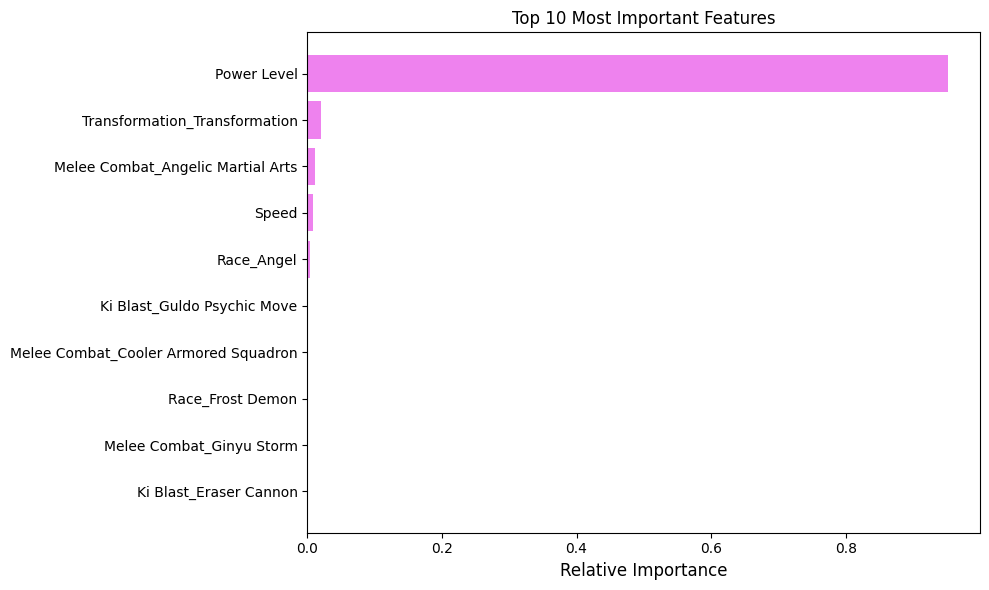

```python
# Ensure feature importances come from the trained model
importances = grad_regressor.feature_importances_

# Get feature names
features = list(x_train.columns)

# Sort feature importances in descending order
indices = np.argsort(importances)[::-1]

# Select top 10 most important features
top_n = 10
top_indices = indices[:top_n]

# Increase figure size for better readability
plt.figure(figsize=(10, 6))

# Title
plt.title("Top 10 Most Important Features")

# Horizontal bar chart with better spacing
plt.barh(range(top_n), importances[top_indices], color='violet', align='center')

# Adjust y-axis labels and rotate for readability
plt.yticks(range(top_n), [features[i] for i in top_indices], fontsize=10)

# Label x-axis
plt.xlabel("Relative Importance", fontsize=12)

# Invert y-axis to show most important at the top
plt.gca().invert_yaxis()

# Adjust layout to prevent label overlap
plt.tight_layout()

# Show the plot
plt.show()
```

## Business Insights and Recommendations

Recommendations

- Model Selection for Production Use
  - Use Gradient Boosting or XGBoost for the final deployment model, as they provide the best balance of accuracy and interpretability. Avoid simple decision trees as they overfit and generalize poorly.
- Feature Engineering & Data Refinement
  - Further refine transformation and combat-related attributes to improve model interpretability.
  - Consider grouping similar attributes to reduce dimensionality and improve performance.
- Hyperparameter Tuning for Optimization
  - Implement RandomizedSearchCV or GridSearchCV to optimize key parameters further.
  - Consider ensembling multiple models to improve stability.
- Application in Real-World Scenarios
  - The model can assist in game balancing, AI-generated rankings, and power scaling debates.
  - Future work could incorporate deep learning techniques for better pattern recognition.

```python
# google

path_ipynb = '/content/drive/MyDrive/My DS DA/Dragon Ball Z/6 Supervised Learning Classification Regression with DT, RF, Ada, GB, XGBoost.ipynb'
notebook_path = path_ipynb

!jupyter nbconvert --to html "{notebook_path}"

from google.colab import files
path_html = '/content/drive/MyDrive/My DS DA/Dragon Ball Z/6 Supervised Learning Classification Regression with DT, RF, Ada, GB, XGBoost.html'

files.download(path_html)
```

[output not shown]

[output cut: 136 more lines]

[output not shown]

[output not shown]